# Assignment 4: Water Quality in Rivers

Haoyu Zhang

## OVERVIEW

This exercise accompanies the lessons in Hydrologic Data Analysis on water quality in rivers.

## Directions

1. Change “Student Name” on line 3 (above) with your name.
2. Work through the steps, **creating code and output** that fulfill each instruction.
3. Be sure to **answer the questions** in this assignment document.
4. When you have completed the assignment, **Knit** the text and code into a single HTML file.
5. After Knitting, submit the completed exercise (HTML file) to the dropbox in Sakai. Add your last name into the file name (e.g., “A04_Chamberlin.html”) prior to submission.

The completed exercise is due on 25 September 2019 at 9:00 am.

## Setup

1. Verify your working directory is set to the R project file,
2. Load the tidyverse, dataRetrieval, cowplot, xts and dygraphs packages.
3. Set your ggplot theme (can be theme_classic or something else)

```r
knitr::opts_chunk$set(echo = TRUE, warning = F)
knitr::opts_chunk$set(fig.width=5.5, fig.height=4, fig.align = "center")

getwd()
```

```
## [1] "D:/William/Duke/Study/EOS 722/Hydrologic_Data_Analysis/Assignments/Assignment 4"
```

```r
packages <- c("tidyverse", "dataRetrieval", "cowplot", "xts", "dygraphs", "lubridate")
invisible(lapply(packages, library, character.only = T))
```

```
## Note: As of version 1.0.0, cowplot does not change the
```

```
##   default ggplot2 theme anymore. To recover the previous
```

```
##   behavior, execute:
##   theme_set(theme_cowplot())
```

```r
theme_set(theme_classic())
```

## Hypoxia

This assignment will look at another measure of water quality - oxygen concentration. Though not directly important for human health, oxygen in the water column is very important for aquatic life, and so is considered a measure of water quality. Hypoxia (low oxygen) has many different definitions. For this assignment, we will use 2 mg/L O<sub>2</sub> as our cut-off.

4. Import the oxygen water quality data from New Hope Creek at Blands (using `readNWISqw()`, site code `02097314`, parameter code `00300`). Make a data frame called `O2.dat` that includes only the Date and O<sub>2</sub> concentration values. Give your data frame understandable column names.

```r
O2raw <- readNWISqw(siteNumbers = "02097314", parameterCd = "00300",
                     startDate = "", endDate = "")
str(O2raw, give.attr = FALSE)
```

```
## 'data.frame':    79 obs. of  34 variables:
##  $ agency_cd                 : chr  "USGS" "USGS" "USGS" "USGS" ...
##  $ site_no                   : chr  "02097314" "02097314" "02097314" "02097314" ...
##  $ sample_dt                 : Date, format: "1982-12-16" "1982-12-17" ...
##  $ sample_tm                 : chr  "14:00" "10:50" "12:55" "10:15" ...
##  $ sample_end_dt             : logi  NA NA NA NA NA NA ...
##  $ sample_end_tm             : chr  NA NA NA NA ...
##  $ sample_start_time_datum_cd: chr  "EST" "EST" "EST" "EST" ...
##  $ tm_datum_rlbty_cd         : chr  "T" "T" "T" "T" ...
##  $ coll_ent_cd               : chr  "USGS-GAL" "USGS-GAL" "USGS-GAL" "USGS-GAL" ...
##  $ medium_cd                 : chr  "WS" "WS" "WS" "WS" ...
##  $ project_cd                : chr  NA NA NA NA ...
##  $ aqfr_cd                   : chr  NA NA NA NA ...
##  $ tu_id                     : chr  NA NA NA NA ...
##  $ body_part_id              : chr  NA NA NA NA ...
```

[output cut: 20 more lines]

```r
O2raw <- O2raw %>%
  select(Date = sample_dt, Parameter = parm_cd, Value = result_va, everything())%>%
  mutate(Parameter = if_else(Parameter == "00300", "O2", Parameter))
#dplyr:if_else preferred over base:ifelse, b/c of the confomity of yes/no output

O2.dat <- O2raw %>%
  select(Date, O2Value = Value)
```

5. Create a ggplot of oxygen concentrations over time. Include a horizonal line at 2 mg/l to show the hypoxia cutoff.

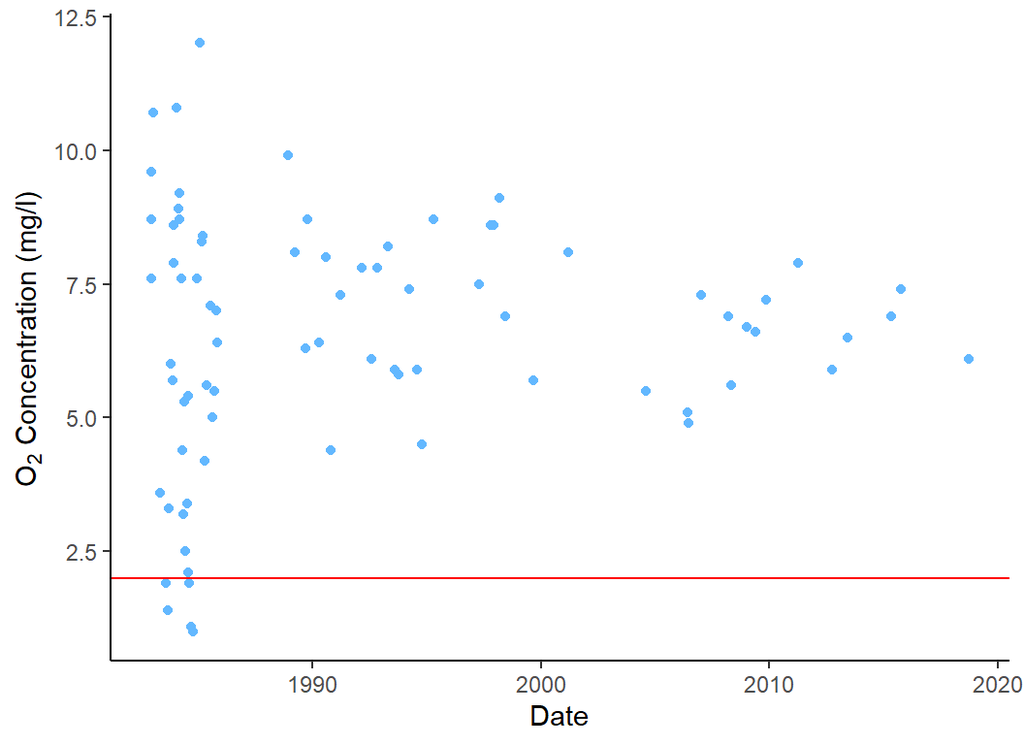

```r
ggplot(O2.dat, aes(x = Date, y = O2Value))+
  geom_point(col = "steelblue1")+
  geom_hline(yintercept = 2, col = "red")+
  labs(y = expression("O"[2]*" Concentration (mg/l)"))
```

6. What do you notice about the frequency of hypoxia overtime?

> Generally, the frequency of hypoxia decreased over time, and since around 1990 the O_2 level in New Hope River never dropped below the 2 mg/l standard.

## Nutrients

7. Often times hypoxia is associated with high nutrient concentrations, because abundant nutrients promote biomass growth which increases respiration and depletes oxygen concentrations in the water (remember how oxygen concentrations were very low in the hypolimnion from the Physical Properties of Lakes week). Create a new data frame, called `nutrients.dat` with total nitrogen (parameter code `00600`) and total phosphorus (parameter code `00665`) data from the USGS. Your data frame should have 3 columns, `Date`, `TotalNitrogen_mgl-N`, and `TotalPhosphorus_mgl-P`.

```r
nutrientsraw <- readNWISqw(siteNumbers = "02097314",
                           parameterCd = c("00600", "00665"),
                           startDate = "", endDate = "")
str(nutrientsraw, give.attr = F)
```

```
## 'data.frame':    115 obs. of  34 variables:
##  $ agency_cd                 : chr  "USGS" "USGS" "USGS" "USGS" ...
##  $ site_no                   : chr  "02097314" "02097314" "02097314" "02097314" ...
##  $ sample_dt                 : Date, format: "1982-12-16" "1982-12-16" ...
##  $ sample_tm                 : chr  "14:00" "14:00" "10:50" "10:50" ...
##  $ sample_end_dt             : logi  NA NA NA NA NA NA ...
##  $ sample_end_tm             : chr  NA NA NA NA ...
##  $ sample_start_time_datum_cd: chr  "EST" "EST" "EST" "EST" ...
##  $ tm_datum_rlbty_cd         : chr  "T" "T" "T" "T" ...
##  $ coll_ent_cd               : chr  "USGS-GAL" "USGS-GAL" "USGS-GAL" "USGS-GAL" ...
##  $ medium_cd                 : chr  "WS" "WS" "WS" "WS" ...
##  $ project_cd                : chr  NA NA NA NA ...
##  $ aqfr_cd                   : chr  NA NA NA NA ...
##  $ tu_id                     : chr  NA NA NA NA ...
##  $ body_part_id              : chr  NA NA NA NA ...
```

[output cut: 20 more lines]

```r
nutrients.dat <- nutrientsraw %>%
  select(Date = sample_dt, Parameter = parm_cd, Value = result_va) %>%
  tibble::rowid_to_column()%>%
# Added b/c a few rows have shared combination of key and value:
# Error: Each row of output must be identified by a unique combination of keys.
# Keys are shared for 4 rows:
# * 21, 23
# * 22, 24
# Do you need to create unique ID with tibble::rowid_to_column()?
  spread(key = Parameter, value = Value) %>%
  rename(TotalNitrogen_mgl = "00600", TotalPhosphorus_mgl = "00665")

# Equivalently
#
#nutrients.dat <- nutrientsraw %>%
#  select(Date = sample_dt, Parameter = parm_cd, Value = result_va) %>%
#  mutate(Parameter=if_else(Parameter == "00600", "TotalNitrogen_mgl-N", Parameter),
#         Parameter=if_else(Parameter == "00665", "TotalPhosphorus_mgl-P",Parameter)) %>%
#  tibble::rowid_to_column()%>%
#  spread(key = Parameter, value = Value)
```

8. Create two ggplots stacked with cowplot that show nutrient concentrations over time.

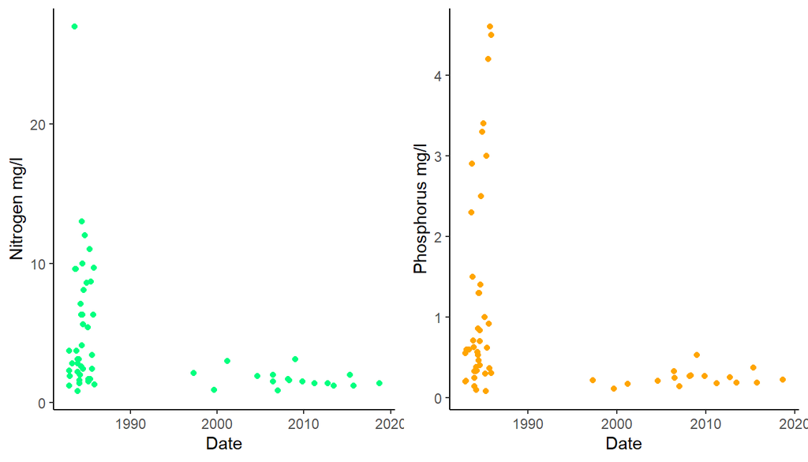

```r
p1 <- ggplot(nutrients.dat, aes(x = Date, y = TotalNitrogen_mgl))+
  geom_point(col = "springgreen", na.rm = T)+ #remove NA created by rowid_to_column()
  labs(x = "Date", y = "Nitrogen mg/l")

p2 <- ggplot(nutrients.dat, aes(x = Date, y =  TotalPhosphorus_mgl))+
  geom_point(col = "orange", na.rm = T)+
  labs(x = "Date", y = "Phosphorus mg/l")

plot_grid(p1, p2)
```

9. What do these plots tell you about nutrient concentrations over time? How might this relate to your previous plot of hypoxia events?

> The nutrient (N, P) level was rather high before 1990, and has decreased since around 1990. The frequent occurence of hypoxia before 1990 could be attributed to the high nutrient concentration during that period.

## Discharge and Temperature

10. Turbulent flow in rivers mixes oxygen into the water column. As discharge decreases, water moves slower, and oxygen diffuses slower into the water from the atmosphere. Download and reformat the daily discharge data for New Hope Creek (function `readNWISdv()`, site `02097314`, parameter `00060`).

```r
dischargeraw <- readNWISdv(siteNumbers = "02097314", parameterCd = "00060",
                           startDate = "", endDate = "")
str(dischargeraw, give.attr = F)
```

```
## 'data.frame':    13507 obs. of  5 variables:
##  $ agency_cd       : chr  "USGS" "USGS" "USGS" "USGS" ...
##  $ site_no         : chr  "02097314" "02097314" "02097314" "02097314" ...
##  $ Date            : Date, format: "1982-10-01" "1982-10-02" ...
##  $ X_00060_00003   : num  12 11 12 11 12 11 12 12 12 12 ...
##  $ X_00060_00003_cd: chr  "A" "A" "A" "A" ...
```

```r
discharge.dat <- dischargeraw %>%
  rename("Discharge" = X_00060_00003, "D.Approval.Code" = X_00060_00003_cd)
```

11. Create a dygraph of discharge and oxygen concentrations. You should have discharge on the y axis and oxygen concentration on the y2 axis. Set your y-axes limits so that they don’t change as you zoom in and out. (hint: use `dyAxis(..., valueRange = c(0, 6500))` for discharge & `dyAxis(..., valueRange = c(0, 13))` for oxygen).

```r
O2 <- with(O2.dat, xts(x = O2Value, order.by = Date))
Discharge <- with(discharge.dat, xts(x = Discharge, order.by = Date))
range(O2)
```

```
## [1]  1 12
```

```r
DyDat <- cbind(O2, Discharge)

dygraph(DyDat) %>%
  dySeries("O2", axis = "y2") %>%
  dyAxis(name = "y", label = "Discharge ft^3/s", valueRange = c(0, 6500)) %>%
  dyAxis(name = "y2", label = "Oxygen Concentration mg/l", valueRange = c(0, 12))%>%
  dyRangeSelector()
```

[interactive chart not shown]

12. Do hypoxic events happen in the wet or the dry season? How many days after storm events (of at least 100 cfs) do they occur?

> Hypoxia occurs in dry season and as early as ~2 weeks after a storm event of at least 100 ft^3 s^-1 (e.g. hypoxia on Oct 16, 1984 after a small discharge peak on Oct 1)
13. Temperature also impacts the solubility of oxygen in water. More oxygen can dissolve when temperatures are *lower*. How would you analyze the effects of temperature on dissolved oxygen concentrations? What data would you need? How would you separate the effects of temperature from the effects of flow?

> To investigate the impact of temperature, data on temperature during the same time frame as O_2 data are required. If discharge is still a variable of interest, we may use multiple linear regression to evaluate the significance of both temperature and discharge rate in explaining variations in O_2 level. If not, we may use temperature as the main effect and take discharge into account as a covarie. Alternatively, we can also compare O_2 level with different temperature but the same discharge.
14. What do you think is the biggest driver of hypoxia in New Hope Creek? What data do you use to support your conclusion?

> I would argue eutrophication is the main cause for hypoxia in New Hope Creek. After After 1990, dry season in which discharge is less 100 ft^3 s^-1 is still present and actually fairly common, but O_2 level never drops below 2 mg/l since then. By contrast, the nutrient levels of N and P is much lower after 1990, and never reach the pre-1990 level. Thus, nutrient is most likely the reason for hypoxia.

## Reflection

15. What are 2-3 conclusions or summary points about river water quality you learned through your analysis?

> Three major factors could play roles in affecting water O_2 concentration: nutrient level (N and P), discharge rate, and temperature. As shown in the case of New Hope Creek, nutrient is the most critical one. However, we did not analyze temperature here, so its relative extent of influence is unknown.
16. What data, visualizations, and/or models supported your conclusions from 15?

> The conformity between the trend of N, P concentration and O_2 level is clearly shown by the diagrams. It would be interesting if we could somehow test the correlation by statistical models. But since data on two variables are not always collected at the same time, this could be challenging or even unfeasible.
17. Did hands-on data analysis impact your learning about water quality relative to a theory-based lesson? If so, how?

> I would not say this is much better than a theory-based lesson in terms of understanding the impact of eutrophication, but again having chances to get familiar with R language and use it for real-world data analysis is always valuable. Also, the dynamic diagrams created by `dygraph` are definitely awesome.
18. How did the real-world data compare with your expectations from theory?

> They are in accordance with my expectation, and the difference in O_2 level before and after the decline of nutrients is quite obvious.